# Support Vector Machines

Gareth Bayvel

# Hard Margin SVM

$$\underset{w}{min}\frac{1}{2}\|w\|^{2}$$$$st.\forall i, y_i(w.x+b)\geq 1$$

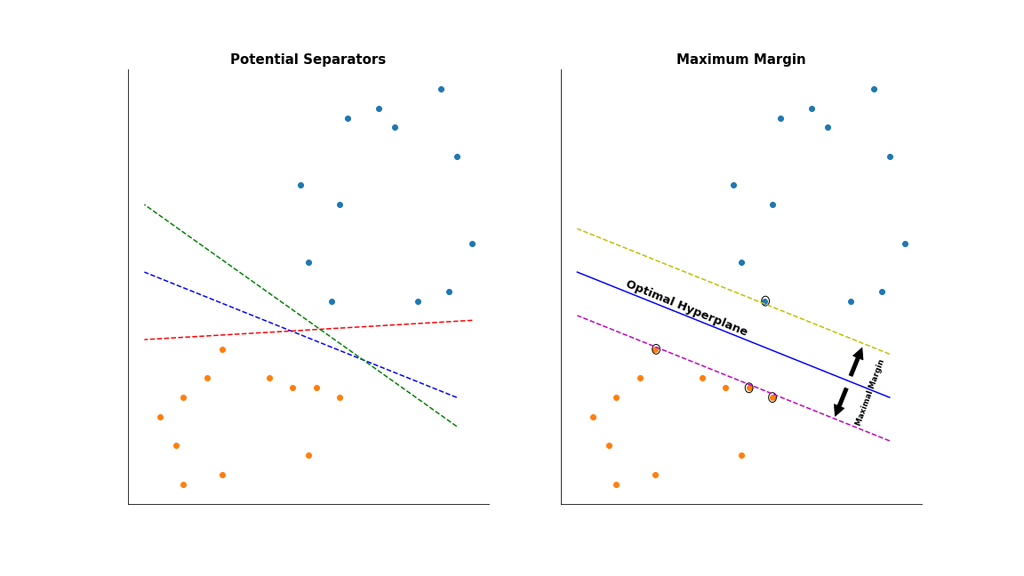

```python
Image('PotentialvsMaximum.png')
```

# Soft Margin SVM

Allow margin violations

$$\underset{w,b,\xi_i \geq 0}{min}\quad\frac{1}{2}\|w\|^{2} + C\sum_{i=1}^{n}\xi_i$$$$st.\forall i, y_i(w.x+b)\geq 1 -\xi_i $$

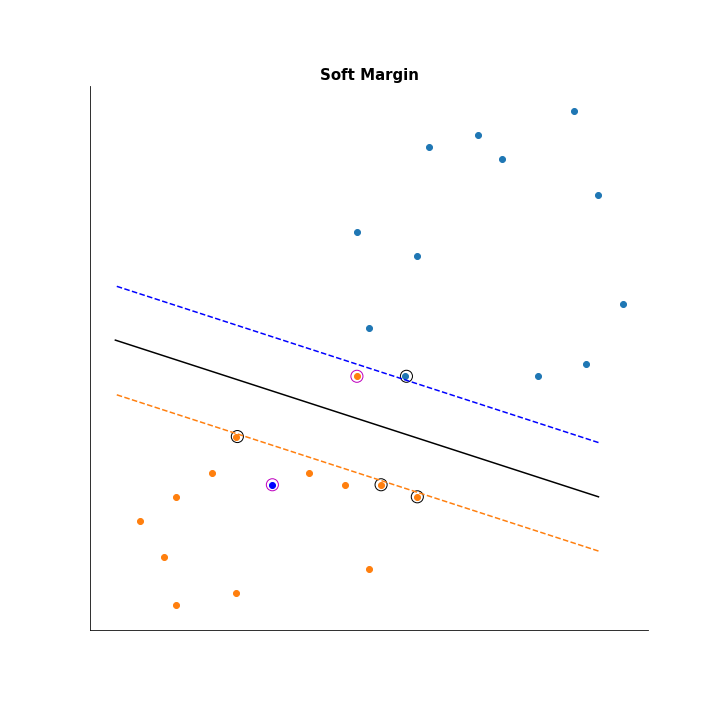

```python
#Plot code contained in appendix
Image('softMarginPlot.png')
```

# SVM Intution

1. The goal of the support vector machine algorithm is to construct a hyper-plane or a set of hyper-planes in N-dimentional space (N is our number of features), which can be used for classification or regression tasks.
1. A good separating hyper-plane is one that achieves the largest distance to the nearest training observations of any class (functional margin).
1. The figure below shows the decision function for a linearly separable problem, with four samples on the margin boundaries, called “support vectors”.
1. Support vectors are observations that are closer to the hyperplane and influence the position and orientation of the hyper-plane.
1. We can see in our left plot that there are many possible hyper-plans that could be chosen to separate our two class.
1. Since a good separating hyper-plane is one that achieves the largest distance (maximum margin) to the nearest training observations, we are more confident that future observations will be classified correctly.

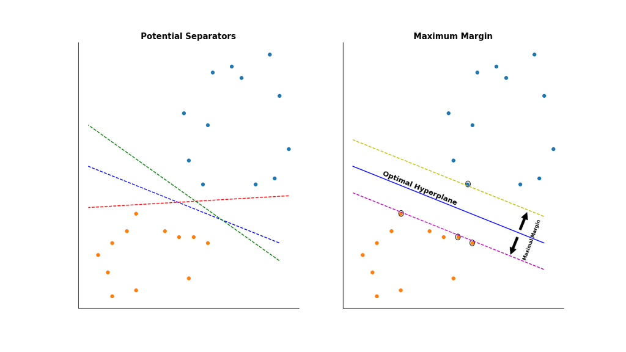

```python
#Plot code contained in appendix
Image('PotentialvsMaximum.png')
```

# Hyper-plane in 3-Dimentional Space is a Plane

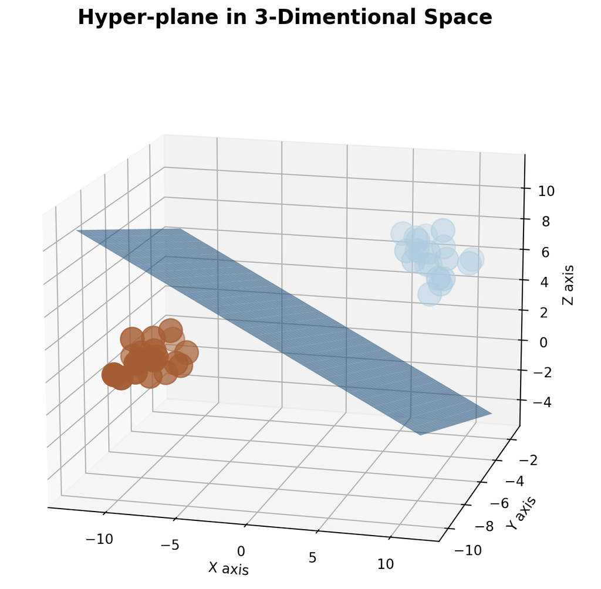

```python
Image('3Dplot.png')
```

# SVM Application Example

- Notably, the logistic regression algorithm takes the output of a linear function and maps that value into the range of [0,1] using the sigmoid function. We know that logistic regression uses a threshold of 0.5 to assign whether an observation belongs to one of the two classes.
- The SVM algorithm takes the output of a linear function and if that output is greater than 1, we classify it as belonging with one class and if the output is -1, we classify it as belonging with another class. Our SVM thus has a reinforcement range of values [-1,1] which acts as our margins.

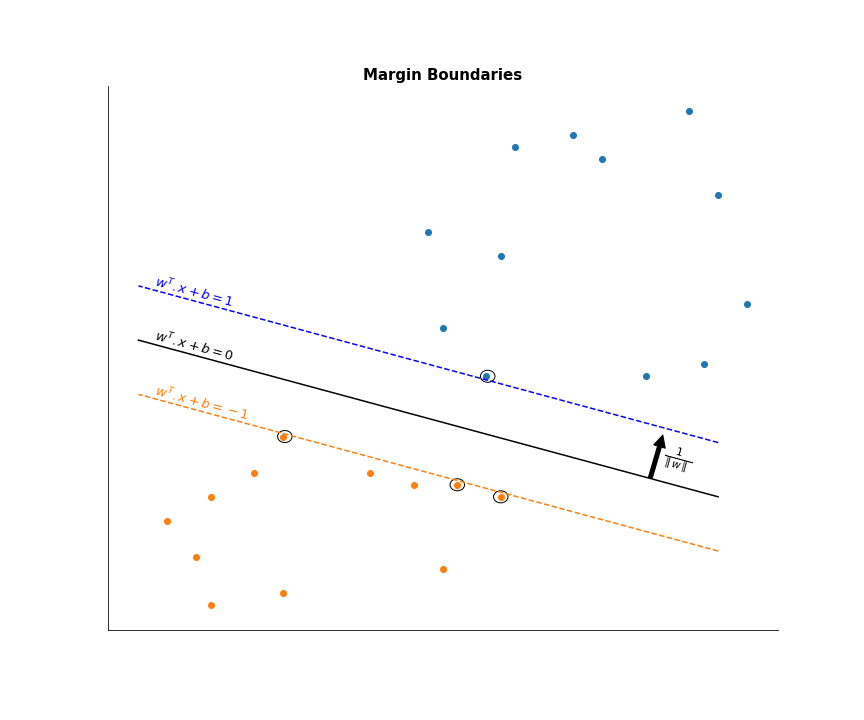

```python
Image('SVM.png')
```

## Spam Filtering

#### We see SVM application in spam filtering where our dependent variable $y_i \in \{-1,1\}$ namely not spam and spam.

- Our class space $y$ is binary and thus this is a binary classification problem.
- To do this classification we use linear models

#### So think in terms of a linear equation:

$$ f(x) = \begin{cases} +1 & \quad \text{if } w^{(1)}x^{(1)}+w^{(2)}x^{(2)}+ . . . + w^{(d)}x^{(d)} \geq \theta \\ -1 & \quad \text{otherwise } \end{cases} $$

1. We will predict that the email is spam if the weighted combination of words in the document (independent variables $x$) is greater than some threshold ($\theta$) theta, otherwise we will predict not spam.
1. Notably, our decision boundary is linear as seen above.
1. Therefore we want to find our black line above where $w.x = \theta$
1. If our weighted function is positive (follows the blue line direction) we make one prediction and vis versa.
1. Our goal is to find $w$ such that our line $w.x = \theta$ separates spam from non-spam. We can see this above with our black line separating spam from ham.

# Largest Margin

This is were SVM gets its nickname large margin classifier

#### In SVM literature we denote our Margin as $\gamma$:

- Our margin is defined by the distance of the closest observations from the decision line/hyperplane which we know are our support vectors.
1. We can see that the second plot below has a larger margin $\gamma$ meaning the distance to the closest observations is larger than in plot one.
   - Thus, only four observation points will be non-zero at the optimal solution to our optimization problem.
   - This makes predictions in higher-dimentional space much for efficient.
   - Only uses these support vectors (subset of training points) in the decision function making this algorithm memory efficient.

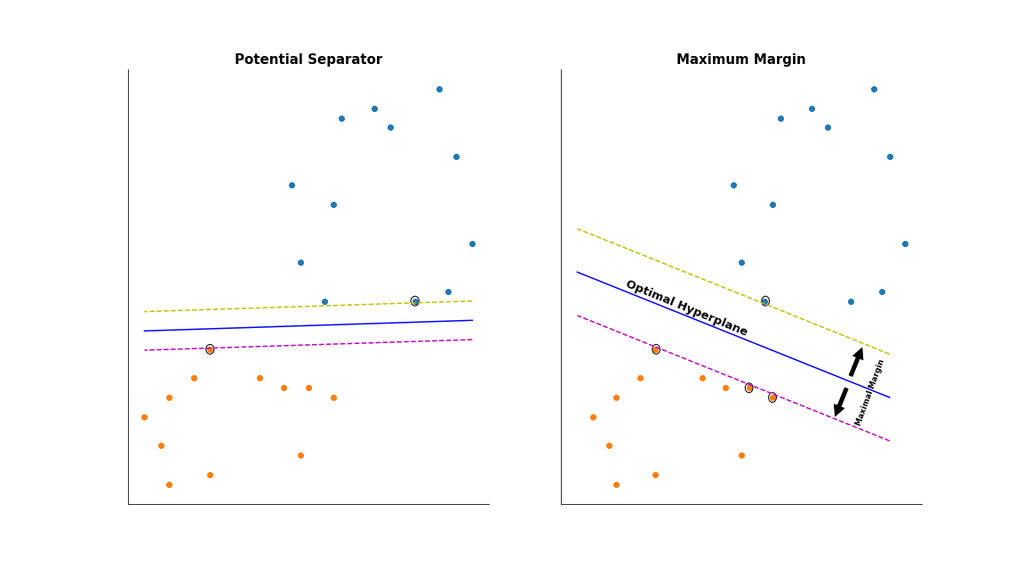

```python
#Plot code contained in appendix
Image('separator.png')
```

## Linear Algebra Concepts

### Linear Projections

$$ \text{Projection Equation} = (b-a\beta)$$

- $\beta$ is our scaler and the point is that we want a scaled version of this line to be as close to b without leaving the line. Therefore, the closest point would be where $b$ meets $a$ at a 90 degree angle.
- We know that If **b** is orthogonal/perpendicular to **$a\beta$** then their dot product must equal zero:

$$ a^{T}(b-a\beta) = 0$$$$ a^{T}b - a^{T}a\beta = 0$$$$ a^{T}a\beta = a^{T}b $$

#### Because we are dealing with dot products of vectors we can divide them (cannot divide matrices):

$$ \beta = \frac{a^{T}b}{a^{T}a} $$

$$a^Tb = \begin{bmatrix} 4& 2 \end{bmatrix} \begin{bmatrix} 1\\[0.1em] 3 \end{bmatrix} = 10$$$$a^Ta = \begin{bmatrix} 4& 2 \end{bmatrix} \begin{bmatrix} 4\\[0.1em] 2 \end{bmatrix} = 20$$$$\beta = \frac{1}{2}$$$$a\beta = \begin{bmatrix} 2\\[0.1em] 1 \end{bmatrix}$$

[figure not shown]

```python
Image('LinProjection.png')
```

# SVM Margin

#### Say we have a line **L** defined by a linear function:

$$w.x+b= w^{(1)}x^{(1)}+w^{(2)}x^{(2)} + b = 0$$

#### An observation **A**:

$$x_A^{(1)},x_A^{(2)} = \begin{bmatrix} 1\\[0.1em] 3 \end{bmatrix} $$

#### An orthonormal vector w:

$$w = w^{(1)},w^{(2)} = \begin{bmatrix} w^{(1)}\\[0.1em] w^{(2)} \end{bmatrix} $$

#### An arbitrary point that lays anywhere along our line **L** which we will just call **M**:

$$x_M^{(1)},x_M^{(2)} = \begin{bmatrix} x_M^{(1)}\\[0.1em] x_M^{(2)} \end{bmatrix} $$

#### We would like to find the distance between A and our Line namely what is the distance of that projection:

$$d(A,L) = |AH|$$

$$|(A-M).w|$$

#### Since M belongs to the Line M = -b

#### Therefore, the **distance** of point A and the Line is simply the orthogonal vector w dotted with A plus the offset term b:

$$= w.A+b$$

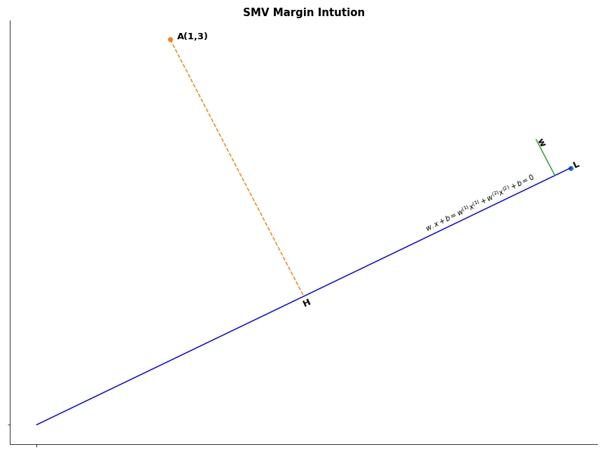

```python
Image('MarginVis.png')
```

## Worked Example

#### Linear Projection

$$ \beta = \frac{a^{T}b}{a^{T}a} $$

$$L^Tb = \begin{bmatrix} 4& 2 \end{bmatrix} \begin{bmatrix} 1\\[0.1em] 3 \end{bmatrix} = 10$$$$L^TL = \begin{bmatrix} 4& 2 \end{bmatrix} \begin{bmatrix} 4\\[0.1em] 2 \end{bmatrix} = 20$$$$$$

$$\beta = \frac{1}{2}$$

$$L\beta = \begin{bmatrix} 2\\[0.1em] 1 \end{bmatrix}$$

#### Euclidean Distance

$$\sqrt{(L\beta^{(1)} - b^{(1)})^2 + (L\beta^{(2)} - b^{(2)})^2}$$$$$$

$$\sqrt{(2 - 1)^2 + (1 - 3)^2} = 2.236$$

#### Using our SVM Formula

$$w.A+b$$

#### Since **w** is orthonormal to **L**:

$$\begin{bmatrix} 4& 2 \end{bmatrix} \begin{bmatrix} x\\[0.1em] y \end{bmatrix} = 0$$$$$$$$ = \begin{bmatrix} 1\\[0.1em] -2 \end{bmatrix}$$

#### Unitary **w**:

$$\overrightarrow{w} = \sqrt{(1)^2 + (-2)^2}. \begin{bmatrix} 1\\[0.1em] -2 \end{bmatrix}$$$$$$

$$ = \begin{bmatrix} -\frac{\sqrt{5}}{5}\\[0.1em] \frac{2\sqrt{5}}{5} \end{bmatrix}$$

#### Distance

$$ \begin{bmatrix} 1& 3 \end{bmatrix}. \begin{bmatrix} -\frac{\sqrt{5}}{5}\\[0.1em] \frac{2\sqrt{5}}{5} \end{bmatrix} = 2.236$$

## Hard SVM Equation

Now for our SVM Equation we know that $w.x+b$ is the distance of our observations to the hyper-plane as it is simply the orthogonal vector w dotted with our observations plus the offset term b:

$$\underset{w}{min}\frac{1}{2}\|w\|^{2}$$$$$$

$$st.\forall i, y_i(w.x+b)\geq 1$$

## So how will we use this knowledge of projections to form our classification algorithym?

#### Our prediction is based upon whether the resultant sign of our projection is positive/negative.

$$sign(w.x+b)$$

#### Our confidence in our prediction for the $i^th$ observation is denoted as:

$$\gamma_i = (w.x+b)y_i$$

#### Misclassification will result in a negative sign.

- This is our prediction multiplied by the true class for the $y_i$.
- If our prediction is negative and class is negative then we get positive.
- If prediction is negative and class is positive then we get negative.

## What Do We Want To Solve

We want to find w (the separating hyperplane) such that all our training data has a margin that is as large as possible.

#### Find w where the smallest margin $\gamma$ is as large as possible

$$\underset{w}{max}\ \underset{i}{min} \gamma_i$$

#### Find w that Maximizes our margin $\gamma$

$$\underset{w,y}{max}\ \gamma $$

#### Such that (s.t) For all our training examples $\forall i$ The margin of our training example $y_i(w.x+b)$ is atlest $\gamma$

$$st.\forall i, y_i(w.x+b)\geq \gamma$$

# How do we find the vector w that maximises our margin?

#### Canonical Hyperplane problem

This issue with maximizing our margin is that if we arbitrarly scale our weight vector this results in our margin also increasing.

$$(w.x+b)y = \gamma$$$$(2w.x+2b)y = 2\gamma$$

#### The solution is to normalize our w such that:

$$\gamma = (\frac{w}{\|w\|}.x+b)y$$$$\|w\| = \sqrt{\sum_{i=1}^{d}(w^{(j)})^{2}}$$

#### We will also require that our support vector $x_j$ will be on the plane defined by w such that:

$$w.x_j+b = \pm 1$$

#### We have seen from our plots that our support vectors lay on the lines:

$$w.x_1+b =-1$$$$w.x_2+b =1$$

#### Canonical Hyperplane Solution

#### What do we know so far: Since we have normalized $w$ the length of the margin on either side is:

$$\frac{w}{\|w\|}$$

#### The relationship between $x_1$ and $x_2$:

$$x_1 = x_2+2\gamma \frac{w}{\|w\|}$$$$$$

Notably, $2\gamma \frac{w}{\|w\|}$ comes from the fact that either side of the margin is $\frac{w}{\|w\|}$ denoted in terms of our margin $\gamma$

#### We also know that our support vector lay on the lines:

$$w.x_1+b =-1$$$$w.x_2+b =1$$

#### Solving our simulataneous equation:

$$w.x_1+b =-1$$$$x_1 = x_2+2\gamma \frac{w}{\|w\|}$$$$$$

$$= w(x_2 + 2\gamma \frac{w}{\|w\|}) +b = 1$$

$$= (w.x_2 +b) + 2\gamma \frac{w.w}{\|w\|} = 1$$

#### $w.x_2 +b$ we know is just equal to -1

$$\gamma = \frac{\|w\|}{w.w} = \frac{1}{\|w\|} $$

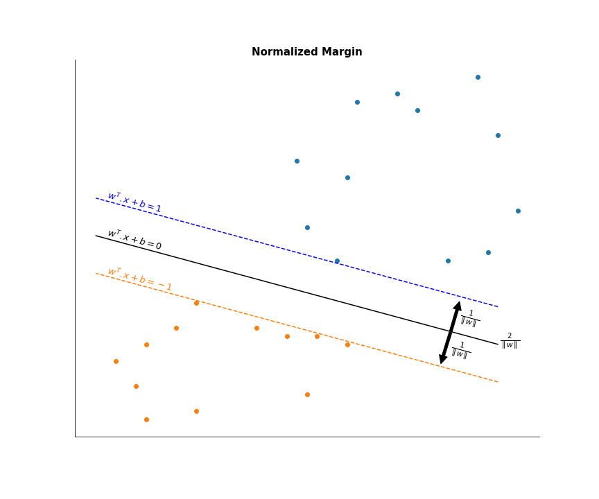

```python
Image('marginGamma.png')
```

# Maximizing The Margin By Minimizing

#### So we first start with our optimiztion problem

$$\underset{w,y}{max}\ \gamma $$$$st.\forall i, y_i(w.x+b)\geq \gamma$$

- This stated that we want to find $w$ such that the margin is maximized and the margin for the distance of all the data points have the confidence greater than $\gamma$
- However, we noted (Canonical problem) that this optimization problem can be solved trivially by making $w$ as large as possible, so this is not usefull

#### That is why we have normalized $w$

$$\underset{max}{\gamma}\approx max \frac{1}{\|w\|} \approx min \frac{1}{2}\|w\|^{2}$$

# Hard Margin SVM

$$\underset{w}{min}\frac{1}{2}\|w\|^{2}$$$$st.\forall i, y_i(w.x+b)\geq 1$$

#### We are trying to minimize $w$ such that it has the smallest length which is the same as maximizing the margin

$$\underset{w}{min}\frac{1}{2}\|w\|^{2}$$

#### Such that for all our training examples they have a confidence greater than 1

$$st.\forall i, y_i(w.x+b)\geq 1$$

# What do we do if we have Non-Linearly Separable data?

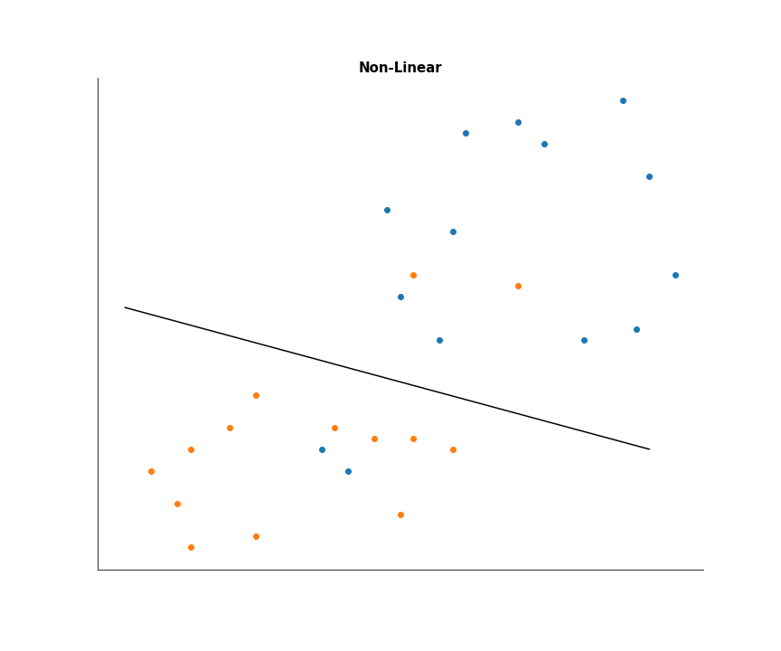

```python
Image('nonSeparable.png')
```

## Introducing A Slack Penalty

If data is not separable we need to introduce a penalty, Meaning we want to allow for some margin violation.

#### We are still looking for a w that maximizes our margin by minimizing $\frac{1}{2}\|w\|^{2}$ whilst allowing for some margin violations

$$\underset{w}{min}\frac{1}{2}\|w\|^{2} + C(violations)$$$$st.\forall i, y_i(w.x+b)\geq 1$$

# Soft Margin SVM

#### How to Penalize Mistakes as not all Mistakes are equally bad

#### Slack Variable is introduced $\xi$

- Our goal is to find w, b and the slack varialbe $\xi$ such that the norm of w is small, meaning the margin is large plus the sum of the penalty (margin violations) $\xi$ is as small as possible
- Such that the confidence in our classification is atlest 1 and if it is not one we subtract the value of $\xi$
- When we correctly classify and our confidence is $\geq1$ we can set $\xi$ to 0

$$\underset{w,b,\xi_i \geq 0}{min}\quad\frac{1}{2}\|w\|^{2} + C\sum_{i=1}^{n}\xi_i$$$$st.\forall i, y_i(w.x+b)\geq 1 -\xi_i $$

### The value of the slack varaible (penalty) will be the distance from the other side of the margin to the data point.

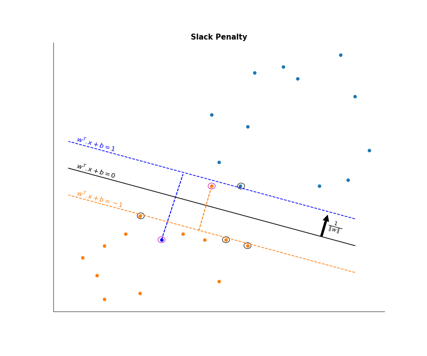

```python
Image('SlackPenalty.png')
```

# Natural Form of SVM

$$\underset{w,b}{argmin}\quad\frac{1}{2}\|w\|^{2} + C\sum_{i=1}^{n}max\{0,1-y_i(w.x_i+b)\}$$$$st.\forall i, y_i(w.x+b)\geq 1 -\xi_i $$

1. Our goal is to find b,w such that our margin is maximized by minimizing $\frac{1}{2}\|w\|^{2}$
1. $C$ is our regularization term. How much are we allowing margin violations.
1. $max\{0,1-y_i(w.x_i+b)\}$: empirical loss L (how well are we fitting our training data)
1. The left part $\frac{1}{2}\|w\|^{2}$ is trying to max the margin i.e find a good separator while the right side is trying to fit the data as best as possible and the cost of how well we are fitting the data is our empirical loss

## Hinge Loss

- Standard 0/1 loss results in a misclassification being penalized by 1 and a correct classification receiving 0.
- Hinge loss has a hinge at 1 meaning a correct classification (point away from the margin) then we obtain the loss of 0
- If classified correctly but within the margin (i.e too close to the margin or on the wrong side of the margin) then we are incurring a penalty proportional to how far away our point is from decision boundary. We can see as the red dotted line below cross the y axis this miscalssification is on the wrong side of the margin and the futher away the higher the line increases i.e the higher the penalty.
- SVM is optimizing this hinge loss in the $max\{0,1-y_i(w.x_i+b)\}$
- Since $\|w\|^{2}$ this is a quadratic objective function and the standard way to solve this is with a quadratic solver software (generally slow and innefficient for large data).

#### Inncorrect classification is (1 - distance from the boundary)

$$1-y_i(\sum_{j=1}^{d}w^{(j)}x^{(j)}_i+b)$$

#### Correct classification is:

$$0$$

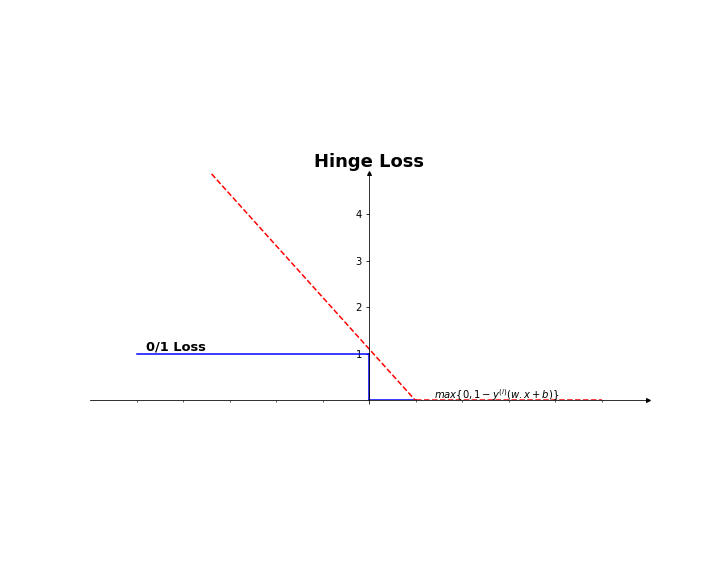

```python
Image('hingeLoss.png')
```

# Gradient Descent

Our function is a quadratic function and convex. Therefore, we can use gradient descent to min our function.

#### Find $w,b$ that minimizes our function

$$f(w,b) = \frac{1}{2}\sum_{j=1}^{d}(w^{(j)})^{2} + C\sum_{i=1}^{n}max\{0,1-y_i(\sum_{j=1}^{d}w^{(j)}x^{(j)}_i+b)\}$$

#### We want to compute the gradient with respect to our weight vector: $\nabla_j\text{ w.r.t }w^{(j)}$

$$\frac{\partial f(w,b)}{\partial w^{j}} \frac{1}{2}\sum_{j=1}^{d}(w^{(j)})^{2} = 2.\frac{1}{2}w^{(j)} = w^{(j)}$$

$$\nabla_j = \frac{\partial f(w,b)}{\partial w^{j}} = w^{(j)}+ C\sum_{i=1}^{n}\frac{\partial L(x_i,y_i)}{\partial w^{j}}$$

$$\frac{\partial L(x_i,y_i)}{\partial w^{j}} = 0 \quad \text{if } y_i(w^{(j)}x^{(j)}_i+b) \geq 1$$$$$$$$ \text{otherwise } = -y_ix^{(j)}_i$$

# SVM For Non-Linearly Separable Class Intution

What if the plot on the left, which is in One-dimention (just assume for this purpose), is our training data and we have overlap.

1. Start with training data in a relatively low dimention (1-dimention in our example).
1. Move the data into a higher dimention (Two-dimentions in our example using $x^2$).
1. Find a Support Vector Classifier that classifies the higher dimentional training data into two classes.

### But why not $x^3$?

In order to make the mathematics for SVM possible, SVM uses Kernel Functions to systematically find support vector classifiers in higher dimentions.

1. In our example we used a polynomial kernel which computes the two-dimentional realtionship between each pairs of training observations and those relationships are used to find a support vector classifier.

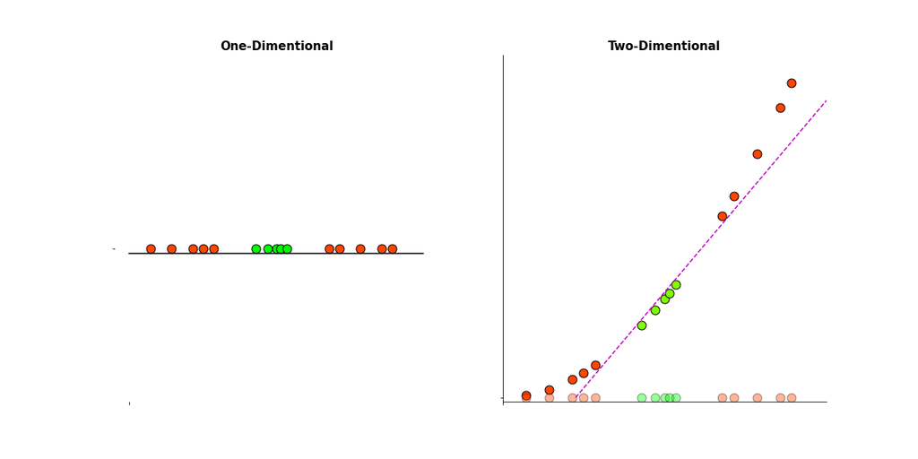

```python
Image('OneD.png')
```

# Non-linear transformations

We have seen that some data is not linearly separable in the original input space. We can apply a transformation to our data in order to map it from its original input space into a higher dimensional feature space. The goal is that in this higher dimensional feature space the classes are now linearly separable and we can fit a decision boundary via a separating hyper-plane.

### Here is an example where our original observations are not linearly separable in two dimensions.

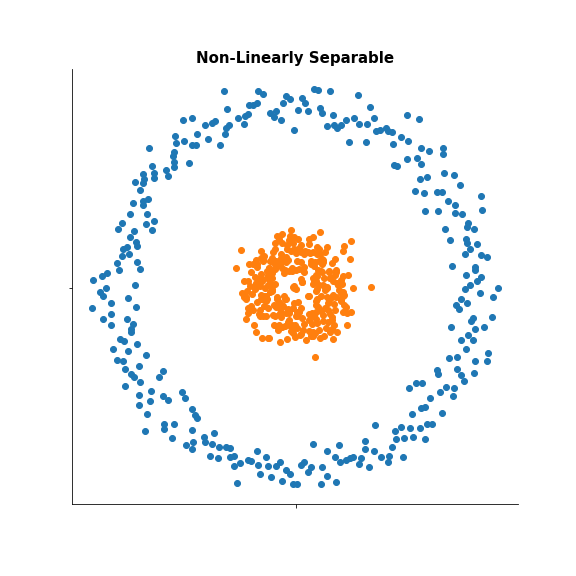

```python
Image('NonLinearly_Separable.png')
```

#### If we map our data to a three-dimensional space using a second-degree polynomial:

$$\phi: \mathbb{R}^{2} \Rightarrow \mathbb{R}^{3} $$$$$$$$\phi(x) = \phi\begin{pmatrix} x_1\\[0.1em] x_2 \end{pmatrix} = \begin{pmatrix} x_1^2\\[0.1em] \sqrt{2}x_1x_2\\[0.1em] x_2^2 \end{pmatrix}$$

#### Our decision boundaries will be hyperplanes in $\mathbb{R}^{3}$, of the form:

$$w^Tx+b = 0$$$$$$$$wx_1^2+w\sqrt{2}x_1x_2+wx_2^2 = 0$$

### Our data is linearly separable in $\mathbb{R}^{3}$.

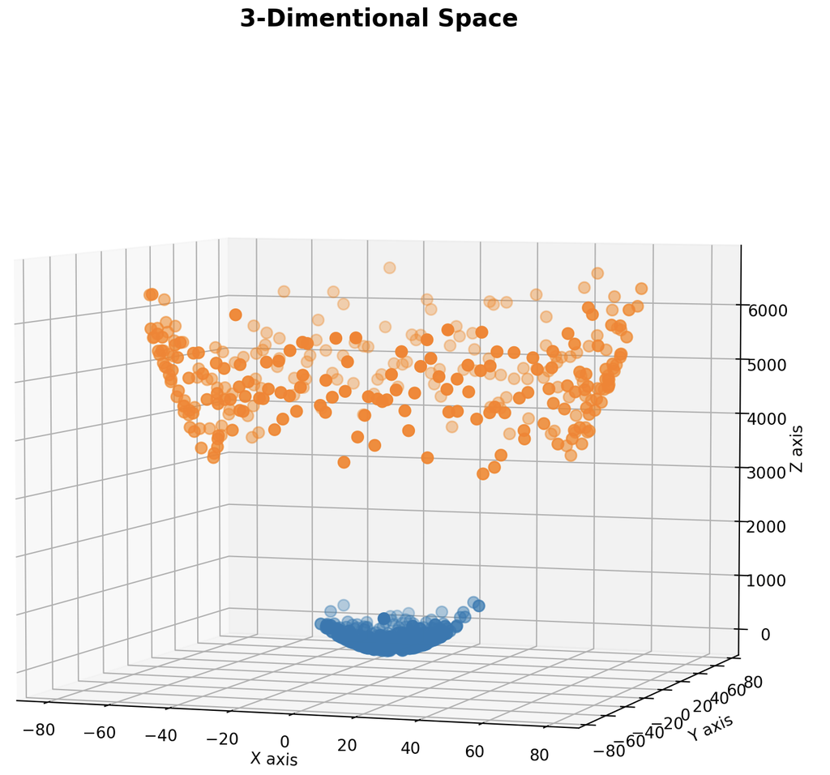

```python
Image('Kernel3D.png')
```

# The Kernel Trick

A function that takes as its inputs vectors in the original space and returns the dot product of the vectors in the feature space is called a Kernel Function

#### Dot product of the transformed feature vectors

The great thing about the kernel trick is that the objective function we are optimizing to fit the higher dimensional decision boundary only includes the dot product of the transformed feature vectors which because our hyper-planes are determined by our support vectors we will have a very sparse matrix with only our support vectors as non-zeros.

#### We have witnessed how higher dimensional transformations allow us to separate our training data for classification predictions.

It would seem that in order to train our support vector classifier and optimize our objective function, we would have to first transform our training observations into higher dimentional vectors in order to perform operations in the transformed feature space. This is impractacle and leads to extremely high computational costs.

### Now enters the "Trick"

The “trick” is that kernel methods represent our training data only through a set of pairwise similarity comparisons between the original training observations x (in the lower dimensional space), instead of explicitly applying the transformations $\phi(x)$ and then representing the new observations in the higher dimensional feature space.

#### In kernel methods, the our training observations X is represented by a square kernel matrix of pairwise similarity comparisons

#### Where the entries (i, j) are defined by the kernel function: $k(x_i, x_j)$.

$$K = \begin{bmatrix} x^T_1x_1 & x^T_2x_2 & \cdots\\ x^T_2x_2& \ddots & \\ \vdots & & \end{bmatrix}_{nxn} $$$$$$

$$X = \begin{bmatrix} x^T_1 \\ \vdots\\ x^T_n \end{bmatrix}_{n*d} $$

### If we first had to map our data via some function $\phi$

$$K = \begin{bmatrix} \phi(x_1)^T\phi(x_1) & \phi(x_2)^T\phi(x_2) & \cdots\\ \phi(x_2)^T\phi(x_2)& \ddots & \\ \vdots & & \end{bmatrix}_{nxn} $$

### Seeing Is Believing

To understand how the kernel function is equal to the dot product of the transformed vectors, each coordinate of the transformed vector $\phi(x)$ is simply the application of some function to the coordinates of the corresponding lower dimensional vector x.

#### Consider the kernel trick for the 2nd-degree polynomial because we have visualized this above in our 3-D plot.

$$\phi(a)^T.\phi(b) = \begin{pmatrix} a_1^2\\[0.1em] \sqrt{2}a_1a_2\\[0.1em] a_2^2 \end{pmatrix}^T.\begin{pmatrix} b_1^2\\[0.1em] \sqrt{2}b_1b_2\\[0.1em] b_2^2 \end{pmatrix} = a_1^2b_1^2 + 2a_1b_1a_2b_2 + a_2^2b_2^2 $$$$$$$$ = (a_1b_1 + a_2b_2)^2 = \begin{pmatrix}\begin{bmatrix} a_1\\[0.1em] a_2^2 \end{bmatrix}^T.\begin{bmatrix} b_1\\[0.1em] b_2 \end{bmatrix}\end{pmatrix}^2 = (a_1^T.b_1)^2 $$

Therefore, instead of mapping our data using a function $\phi$ and computing the inner product in the feature space, we can do it in one operation, leaving the mapping completely implicit. Interestingly, we do not even need to know $\phi$ as all we need to know is how to compute the modified inner product.

## Mercer’s Theorem

Tells us that a symmetric function $K(x,y)$ can be expressed as an inner product: $$$$$$K(x,z) = \langle\phi(x),\phi(z)\rangle$$

# Lagrange Multipliers

#### Suppose we have a function $f(x,y) = z$

We know this is a surface.

#### Now suppose we have a contraint $g(x,y)=c$

As this constraint is equal to a constant we know this is a level curve to some surface $g(x,y)=z$

#### If we take our function and set it equal to a constant $f(x,y) = c$

We have a whole set of level curves.

#### For contrained optimization we have to be on the surface of $f(x,y) = c$ meaning we will be on these levels curves.

We also have to be on the constraint $g(x,y)=c$. This specific level curve.

#### We are looking where this specific level curve bounces off our function (constrained maxima or minima)

```
- We know that these functions share common tangents at the point of bouncing off.
- Parrallel Tangents and therefore Parrallel Normals
- The gradient of a Surface gives us normals to the level curves
```

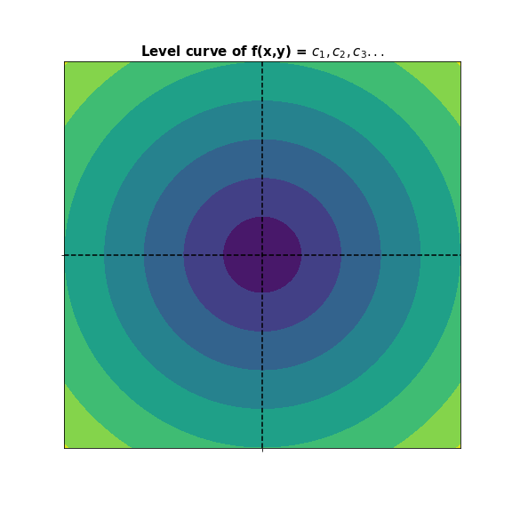

```python
Image('LevelCurves.png')
```

[figure not shown]

```python
Image('3D_levelCurves.png')
```

### If two points intersect and bounce off one another then they share a common tangent or atleast their tangents are scaler multiples

If they share the same tangent then they also have the same normals or atleast the normals are scaler multiples

### The normals of the level curves are scaler multiples

$$\underset{f(x,y)}{NORMALS} = k.\underset{g(x,y)}{NORMALS}$$

#### What gives us normals to level curves? (gradient)

$$\nabla f(x,y) = k. \nabla g(x,y)$$

#### What is the scaler k defined as?

$$\nabla f(x,y) = \lambda \nabla g(x,y)$$

- Lambda $\lambda$ is what we define as the Lagrange Multiplier
- Scaler multiple i.e Lagrange multiple/ier
- Since gradients give us normals of level curves we can extrapolate the same formula for multidimentional functions

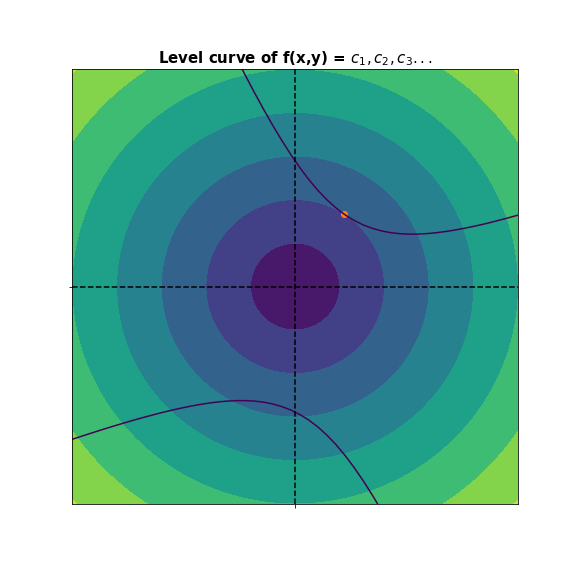

```python
Image('LagrangeOptimization.png')
```

# Lagrange Duality and contstrained optimization problems

#### Given a function and a constraint

$$\underset{x}{min}f(x)$$$$\text{s.t. } g_i(x) = 0$$

#### Our Lagrangian would be:

$$L(w,\beta) = f(x) +\sum_{i=1}^{l}\beta_i g_1(w)$$$$$$

Here our $\beta_i$ is our Lagrangian Multipliers

#### We then set $L’s$ partial derivatives to zero and solve for $x,\beta$

$$\frac{\partial L}{\partial x_i} = 0; \frac{\partial L}{\partial \beta_i} = 0$$

# Optimal Margin Classifier

#### Our goal is to write our algorithm in terms of only the inner product between points in the input feature space.

$$\langle x^{(i)},x^{(j)}\rangle$$

$$$$

The fact that we can express our algorithm in terms of these inner products will be key when we apply the kernel trick.

### The (primal) optimization problem for finding the optimal margin classifier:

$$\underset{w,b,\gamma}{min} \frac{1}{2}\|w\|^{2}$$$$st.y_i(w.x^{(i)}+b)\geq 1$$

#### Using the Lagrangian formula:

$$\underset{x}{min}f(x)$$$$\text{s.t. } g_i(x) = 0$$

$$L(w,\beta) = f(x) +\sum_{i=1}^{l}\beta_i g_1(w)$$

### Our function and constraint can be written as:

$$f(x) =\frac{1}{2}\|w\|^{2}$$$$g_i(x) = −y^{(i)}(w.x^{(i)} + b) +1 \leq 0$$

#### Consturcting our Largrange optimization problem:

$$L(w,b,\alpha) = \frac{1}{2}\|w\|^{2} - \sum_{i=1}^{m}\alpha [y^{(i)}(w.x^{(i)} + b) -1]$$

### Taking the partial derivatives:

$$\nabla_w L(w,b,\alpha) = w - \sum_{i=1}^{m}\alpha_i y^{(i)}x^{(i)} $$

#### This implies that $w$:

$$w = \sum_{i=1}^{m}\alpha_i y^{(i)}x^{(i)} $$

#### Derivative with respect to $b$:

$$\frac{\partial}{\partial b}L(w,b,\alpha) = \sum_{i=1}^{m}\alpha_i y^{(i)} = 0 $$

#### Taking these two derivatives and plugging them into our Largrange optimization problem:

$$L(w,b,\alpha) = \sum_{i=1}^{m}\alpha_i - \frac{1}{2}\sum_{i,j=1}^{m}y^{(i)}y^{(j)}\alpha_i \alpha_j (x^{(i)})^{T}x^{(j)} - b \sum_{i=1}^{m}\alpha_i y^{(i)} $$

$$L(w,b,\alpha) = \sum_{i=1}^{m}\alpha_i - \frac{1}{2}\sum_{i,j=1}^{m}y^{(i)}y^{(j)}\alpha_i \alpha_j \langle x^{(i)},x^{(j)}\rangle$$

## Dual Optimization Problem

- If we have found our $\alpha$'s, in order to make a prediction we only have to calculate a quantity that depends on the inner product between x and the points in the training set.
- Since our $\alpha$'s will all be zero except for the support vectors many of the terms in the sum below will be zero, and we really need to find only the inner products between x and the support vectors (of which there is often only a small number) in order to make our prediction.
- The dual form of the optimization problem, allows us to write the entire algorithm in terms of only inner products between input feature vectors. The resulting algorithm will be able to efficiently learn in very high dimensional spaces.

$$\underset{\alpha}{max} \text{ }W(\alpha) = \sum_{i=1}^{m}\alpha_i - \frac{1}{2}\sum_{i,j=1}^{m}y^{(i)}y^{(j)}\alpha_i \alpha_j \langle x^{(i)},x^{(j)}\rangle$$$$st.\alpha_i \geq 0$$$$\sum_{i=1}^{m}\alpha_i y^{(i)} = 0 $$

#### Since we worked out that:

$$w = \sum_{i=1}^{m}\alpha_i y^{(i)}x^{(i)} $$$$w^{T}x+b = (\sum_{i=1}^{m}\alpha_i y^{(i)}x^{(i)})^{T} x+b$$

#### Our predictions can now be written as:

$$\sum_{i=1}^{m}\alpha_i y^{(i)}\langle x^{(i)},x\rangle +b$$

## Soft Margin optimization problem for finding the optimal margin classifier:

### Primal

$$\underset{w,b}{argmin}\quad\frac{1}{2}\|w\|^{2} + C\sum_{i=1}^{n}\xi_i$$$$st.\forall i, y_i(w.x+b)\geq 1 -\xi_i $$$$st.\forall i, \xi_i \geq 0$$

### Lagrangian

$$L(w,b,\alpha) = \frac{1}{2}\|w\|^{2} + C\sum_{i=1}^{n}\xi_i - \sum_{i=1}^{m}\alpha [y^{(i)}(w.x^{(i)} + b) -1 + \xi_i] - \sum_{i=1}^{m}\mathcal{r}\xi_i$$

## Dual Optimization Problem

$$L(w,b,\xi,\alpha,\mathcal{r}) = \sum_{i=1}^{m}\alpha_i - \frac{1}{2}\sum_{i,j=1}^{m}y^{(i)}y^{(j)}\alpha_i \alpha_j \langle x^{(i)},x^{(j)}\rangle$$$$\text{st}. 0 \leq \alpha_i \leq C$$$$\sum_{i=1}^{m}\alpha_i y^{(i)} = 0 $$

# Dual formulation only depends on dot-products, not on w!

### The Kernel Trick

$$maximize_\alpha \sum_{i=1}^{m}\alpha_i - \frac{1}{2}\sum_{i,j=1}^{m}y^{(i)}y^{(j)}\alpha_i \alpha_j K(x_i,x_j)$$$$\text{st}. 0 \leq \alpha_i \leq C$$$$K(x_i,x_j) = \phi(x_i).\phi(x_j)$$$$\sum_{i=1}^{m}\alpha_i y^{(i)} = 0 $$

#### Since we worked out that the solution to the dual problem gives us:

$$w = \sum_{i=1}^{m}\alpha_i y^{(i)}x^{(i)} $$

#### Our decision Boundary is:

$$w^{T}x+b = (\sum_{i\in SV}^{}\alpha_i y^{(i)}x^{(i)})^{T} x+b$$$$\sum_{i\in SV}^{m}\alpha_i y^{(i)}\langle x^{(i)},x\rangle +b$$

#### Our predictions can now be written as:

$$\hat{y} = sign[\sum_{i\in SV}^{}\alpha_i y^{(i)}\langle x^{(i)},x\rangle +b]$$

#### Mapping to our feature space our prediction is:

$$\hat{y} = sign[\sum_{i\in SV}^{}\alpha_i y^{(i)}(\phi(x^{(i)}),\phi(x)) +b]$$

# Appendix

**Libraries**:

```
import numpy as np
import matplotlib.pyplot as plt
from mpl_toolkits.mplot3d import Axes3D
import seaborn as sns
import pandas as pd
from IPython.display import Image
from sklearn.metrics import r2_score
from sklearn.model_selection import GridSearchCV
from sklearn.datasets import make_regression
import matplotlib.lines as mlines
from sklearn.model_selection import train_test_split
```

**Hard Margin:**

```
# create two classes
class1_x = [3.5,4,5,4.5,3,4.2,4.8,5.2,3.6,4.9,3.1,3.4]
class1_y = [4,5,4.5,3,4.2,4.8,5.2,3.6,4.9,3.1,3.4,3]

class2_x = [1.5,2,1.5,3.5,2,1.2,1.8,3.2,2.6,2.9,3.1,1.4]
class2_y = [2,2.5,1.1,2,1.2,1.8,2.2,2.1,2.2,2.1,1.4,1.5]


# Select length of axes and the space between tick labels
xmin, xmax, ymin, ymax = -5, 5, -5, 5
ticks_frequency = 1

# Plot points
fig, (ax2, ax1)= plt.subplots(1,2,figsize=(16,9))
plt.setp(ax1, xticks=[0], xticklabels=[''],
        yticks=[0], yticklabels=[''])
plt.setp(ax2, xticks=[0], xticklabels=[''],
        yticks=[0], yticklabels=[''])
ax1.scatter(class1_x,class1_y)
ax1.scatter(class2_x,class2_y)

ax1.plot([5,1],[2,3.3],'b',label ='$w.x = 𝜃$')
ax1.plot([5,1],[2.45,3.75],'y--')
ax1.plot([5,1],[1.55,2.85],'m--')

ax2.scatter(class1_x,class1_y)
ax2.scatter(class2_x,class2_y)

ax2.plot([5,1],[2,3.3],'b--',label ='$w.x = 𝜃$')
ax2.plot([5,1],[1.7,4],'g--')
ax2.plot([5.2,1],[2.8,2.6],'r--')

# Showing support vector observations
cir = plt.Circle((2.01, 2.5), 0.05, color='black',fill=False)
cir1 = plt.Circle((3.41, 3), 0.05, color='black',fill=False)
cir2 = plt.Circle((3.5, 2), 0.05, color='black',fill=False)
cir3 = plt.Circle((3.2, 2.1), 0.05, color='black',fill=False)

ax1.add_patch(cir)
ax1.add_patch(cir1)
ax1.add_patch(cir2)
ax1.add_patch(cir3)

# Remove top and right spines
ax1.spines['top'].set_visible(False)
ax1.spines['right'].set_visible(False)
ax2.spines['top'].set_visible(False)
ax2.spines['right'].set_visible(False)

# Providing subplots with titles
ax1.set_title('Maximum Margin',fontweight="bold", size = 15)
ax2.set_title('Potential Separators',fontweight="bold", size = 15)

# Title Annotations and Text
ax1.text(1.6, 2.64, 'Optimal Hyperplane', fontsize = 13, rotation=-22.29,weight='bold')
ax1.annotate('', xy=(4.3, 1.8), xytext=(4.45, 2.1),
            arrowprops=dict(facecolor='black', shrink=0.02))
ax1.annotate('', xy=(4.65, 2.52), xytext=(4.5, 2.22),
            arrowprops=dict(facecolor='black', shrink=0.02))
ax1.text(4.55, 1.72, 'Maximal Margin', fontsize = 8.8, rotation=70,weight='bold')

fig.savefig('PotentialvsMaximum.png')
```

**Soft Margin**:

```
# create two classes
class1_x = [3.5,4,5,4.5,3,4.2,4.8,5.2,3.6,4.9,3.1,3.4]
class1_y = [4,5,4.5,3,4.2,4.8,5.2,3.6,4.9,3.1,3.4,3]

class2_x = [1.5,2,1.5,3.5,2,1.2,1.8,3.2,2.6,2.9,3.1,1.4]
class2_y = [2,2.5,1.1,2,1.2,1.8,2.2,2.1,2.2,2.1,1.4,1.5]
x = np.array([2.3,2.1])
y = np.array([3,3])

# Select length of axes and the space between tick labels
xmin, xmax, ymin, ymax = -5, 5, -5, 5
ticks_frequency = 1

# Plot points
fig, ax1 = plt.subplots(figsize=(10,10))
plt.setp(ax1, xticks=[0], xticklabels=[''],
        yticks=[0], yticklabels=[''])
ax1.scatter(class1_x,class1_y)
ax1.scatter(class2_x,class2_y)

ax1.plot([5,1],[2,3.3],'black',label ='$w.x+b = 0$')
ax1.plot([5,1],[2.45,3.75],'b--')
ax1.plot([5,1],[1.55,2.85],'tab:orange', linestyle = '--')

ax1.scatter(x[0],x[1],c = 'b')
ax1.scatter(y[0],y[1],c = 'tab:orange')
#ax1.plot([2.3,2.7],[2.1,3.2],'b--')
#ax1.plot([2.758,3],[2.25,3],'tab:orange', linestyle = '--')
error1 = plt.Circle((2.3,2.1), 0.05, color='m',fill=False)
error2 = plt.Circle((3,3), 0.05, color='m',fill=False)


# Showing support vector observations
cir = plt.Circle((2.01, 2.5), 0.05, color='black',fill=False)
cir1 = plt.Circle((3.41, 3), 0.05, color='black',fill=False)
cir2 = plt.Circle((3.5, 2), 0.05, color='black',fill=False)
cir3 = plt.Circle((3.2, 2.1), 0.05, color='black',fill=False)

ax1.add_patch(cir)
ax1.add_patch(cir1)
ax1.add_patch(cir2)
ax1.add_patch(cir3)
ax1.add_patch(error1)
ax1.add_patch(error2)

# Remove top and right spines
ax1.spines['top'].set_visible(False)
ax1.spines['right'].set_visible(False)


# Providing subplots with titles
ax1.set_title('Soft Margin',fontweight="bold", size = 15)



# Title Annotations and Text

#ax1.text(1.1, 3.57, '$w^T.x+b = 1$', fontsize = 13, rotation=-18,weight='bold',c = 'blue')
#ax1.text(1.1, 3.12, '$w^T.x+b = 0$', fontsize = 13, rotation=-18,c = 'black')
#ax1.text(1.1, 2.63, '$w^T.x+b = -1$', fontsize = 13, rotation=-18,c = 'tab:orange')

ax1.axis("equal")

fig.savefig('softMarginPlot.png')
```

**3-D Plot:**

```
%matplotlib notebook
#Now we plot a scatter in 3D
#the number 20 for the range of linespace
X, y = make_blobs(n_samples=40, centers=2, n_features = 3 ,random_state=6)
fig = plt.figure(figsize=(8,8)) #To make the figure bigger
ax = plt.axes(projection = '3d')

#To bigger points with s =points^2
ax.scatter3D(X[:, 0], X[:, 1],X[:, 2], c=y, s=300, cmap=plt.cm.Paired);

#To set the labels in x, y and z axis
ax.set_xlabel('X axis')
ax.set_ylabel('Y axis')
ax.set_zlabel('Z axis')
ax.set_title('Hyper-plane in 3-Dimentional Space',fontweight="bold", size = 15)


# create grid to evaluate model
xx = np.linspace(xlim[0], xlim[1], 30)
yy = np.linspace(ylim[0], ylim[1], 30)

YY, XX = np.meshgrid(yy, xx)

np.random.seed(7)
A = np.random.randn(3,2)
cp = np.cross(A[:,0],A[:,1])
z1 = (-cp[0]*XX - cp[1]*yy)*1./cp[2]
ax.plot_surface(XX,yy,z1,alpha = 0.6)
ax.show()
%matplotlib notebook
```

**Plot Three:**

```
# create two classes
class1_x = [3.5,4,5,4.5,3,4.2,4.8,5.2,3.6,4.9,3.1,3.4]
class1_y = [4,5,4.5,3,4.2,4.8,5.2,3.6,4.9,3.1,3.4,3]

class2_x = [1.5,2,1.5,3.5,2,1.2,1.8,3.2,2.6,2.9,3.1,1.4]
class2_y = [2,2.5,1.1,2,1.2,1.8,2.2,2.1,2.2,2.1,1.4,1.5]


# Select length of axes and the space between tick labels
xmin, xmax, ymin, ymax = -5, 5, -5, 5
ticks_frequency = 1

# Plot points
fig, ax1 = plt.subplots(figsize=(12,10))
plt.setp(ax1, xticks=[0], xticklabels=[''],
        yticks=[0], yticklabels=[''])
ax1.scatter(class1_x,class1_y)
ax1.scatter(class2_x,class2_y)

ax1.plot([5,1],[2,3.3],'black',label ='$w.x+b = 0$')
ax1.plot([5,1],[2.45,3.75],'b--')
ax1.plot([5,1],[1.55,2.85],'tab:orange', linestyle = '--')


# Showing support vector observations
cir = plt.Circle((2.01, 2.5), 0.05, color='black',fill=False)
cir1 = plt.Circle((3.41, 3), 0.05, color='black',fill=False)
cir2 = plt.Circle((3.5, 2), 0.05, color='black',fill=False)
cir3 = plt.Circle((3.2, 2.1), 0.05, color='black',fill=False)

ax1.add_patch(cir)
ax1.add_patch(cir1)
ax1.add_patch(cir2)
ax1.add_patch(cir3)

# Remove top and right spines
ax1.spines['top'].set_visible(False)
ax1.spines['right'].set_visible(False)




# Providing subplots with titles
ax1.set_title('Margin Boundaries',fontweight="bold", size = 15)

# Title Annotations and Text

ax1.annotate('', xy=(4.62, 2.52), xytext=(4.53, 2.15),
            arrowprops=dict(facecolor='black', shrink=0.02))
ax1.text(4.6, 2.25, '$\\frac{1}{\\parallel w\\parallel}$', fontsize = 15,rotation=-15.2, weight='bold')
ax1.text(1.1, 3.57, '$w^T.x+b = 1$', fontsize = 13, rotation=-15.2,weight='bold',c = 'blue')
ax1.text(1.1, 3.12, '$w^T.x+b = 0$', fontsize = 13, rotation=-15.2,c = 'black')
ax1.text(1.1, 2.63, '$w^T.x+b = -1$', fontsize = 13, rotation=-15.2,c = 'tab:orange')

fig.savefig('SVM.png')
```

**Kernel 3D**

```
%matplotlib notebook
#Now we plot a scatter in 3D
np.random.seed(7)

#Creating a sequence of points
angle = np.arange(0, np.pi*2, 0.02)
r = 70 + np.random.normal(0,5, angle.shape)
x = r * np.cos(angle)
y = r * np.sin(angle)
z = x**2 + y**2

angle2 = np.arange(0, np.pi*2, 0.02)
r2 = 15 + np.random.normal(0,5, angle2.shape)
x2 = r2 * np.cos(angle2)
y2 = r2 * np.sin(angle2)
z2 = x2**2 + y2**2

fig = plt.figure(figsize=(10,10)) #To make the figure bigger
ax1 = plt.axes(projection = '3d')

#To bigger points with s =points^2
ax1.scatter3D(x, y, z, c = 'tab:orange', s=50);
ax1.scatter3D(x2, y2, z2, c = 'tab:blue', s=50);
#To set the labels in x, y and z axis
ax1.set_xlabel('X axis')
ax1.set_ylabel('Y axis')
ax1.set_zlabel('Z axis')

ax1.set_title('3-Dimentional Space',fontweight="bold", size = 15)
```

**Linear Projection:**

```
# create two vectors
a = np.array([4,2])
b = np.array([1,3])

# Select length of axes and the space between tick labels
#xmin, xmax, ymin, ymax = -5, 5, -5, 5
ticks_frequency = 1

# Plot points for plot 1
fig, (ax1, ax2)= plt.subplots(1,2,figsize=(16,9))
plt.setp(ax1, xticks=[0], xticklabels=[''],
        yticks=[0], yticklabels=[''])
plt.setp(ax2, xticks=[0], xticklabels=[''],
        yticks=[0], yticklabels=[''])
ax1.scatter(a[0],a[1])
ax1.scatter(b[0],b[1])
ax1.plot([0,a[0]],[0,a[1]],'blue',label = 'B')

# Remove top and right spines
ax1.spines['top'].set_visible(False)
ax1.spines['right'].set_visible(False)

# Providing subplots with titles
ax1.set_title('Vectors',fontweight="bold", size = 15)

# Title Annotations and Text
ax1.text(3.7,2.05, 'a(4,2)', fontsize = 13,weight='bold')
ax1.text(1.1,3, 'b(4,2)', fontsize = 13,weight='bold')
#_______________________________________________________________________________

# Plot points for plot 1
ax2.scatter(a[0],a[1])
ax2.scatter(b[0],b[1])
ax2.plot([0,a[0]],[0,a[1]],'blue',label = 'B')

# Projection equation
beta = (a.T@b) / (a.T@a)
ax2.plot([b[0], beta*a[0]],[b[1], beta*a[1]],'tab:orange',linestyle = "--")

# Remove top and right spines
ax2.spines['top'].set_visible(False)
ax2.spines['right'].set_visible(False)

# Providing subplots with titles
ax2.set_title('Linear Projection',fontweight="bold", size = 15)

# Title Annotations and Text
ax2.text(3.7,2.05, 'a(4,2)', fontsize = 13,weight='bold')
ax2.text(1.1,3, 'b(1,3)', fontsize = 13,weight='bold')
ax2.text(1.78,0.8, '$Proj_ab (2,1)$', fontsize = 13,rotation = 25,weight='bold')


ax2.set_title('Potential Separator',fontweight="bold", size = 15)

fig.tight_layout()
ax2.axis('equal')

fig.savefig('LinProjection.png')
```

**Margin Vis**:

```
# create two vectors
a = np.array([4,2])
b = np.array([1,3])
w1 = 1/(np.sqrt(1+4))*4*1.7+0.7
w2 = 1/(np.sqrt(1+4))*2*1.7+0.7
w = np.array([w1,w2])

# Select length of axes and the space between tick labels
#xmin, xmax, ymin, ymax = -5, 5, -5, 5
ticks_frequency = 1

# Plot points for plot 1
fig, ax2= plt.subplots(figsize=(12,9))
plt.setp(ax2, xticks=[0], xticklabels=[''],
        yticks=[0], yticklabels=[''])

# Plot points for plot 1
ax2.scatter(a[0],a[1])
ax2.scatter(b[0],b[1])
ax2.plot([0,a[0]],[0,a[1]],'blue',label = 'B')



# Projection equation
beta = (a.T@b) / (a.T@a)
ax2.plot([b[0], beta*a[0]],[b[1], beta*a[1]],'tab:orange',linestyle = "--")

beta2 = (a.T@w) / (a.T@a)
ax2.plot([w[0], beta2*a[0]],[w[1], beta2*a[1]],'tab:green',linestyle = "-")

# Remove top and right spines
ax2.spines['top'].set_visible(False)
ax2.spines['right'].set_visible(False)

# Providing subplots with titles
ax2.set_title('SMV Margin Intution',fontweight="bold", size = 15)
# Title Annotations and Text
ax2.text(2.9,1.5, '$w.x+b= w^{(1)}x^{(1)}+w^{(2)}x^{(2)} + b = 0$', fontsize = 10, rotation = 26, weight='bold')
ax2.text(1.05,3, 'A(1,3)', fontsize = 13,weight='bold')
ax2.text(1.985,0.92, 'H', fontsize = 13,rotation = 25,weight='bold')
ax2.text(4.01,2, 'L', fontsize = 13,weight='bold',rotation = 25)
ax2.text(3.73,2.17, 'w', fontsize = 13,weight='bold',rotation = -60)

fig.tight_layout()

fig.savefig('MarginVis.png')
```

**Non-Separable**:

```
# create two classes
class1_x = [3.5,4,5,4.5,3,4.2,4.8,5.2,3.6,4.9,3.1,3.4]
class1_y = [4,5,4.5,3,4.2,4.8,5.2,3.6,4.9,3.1,3.4,3]

class2_x = [1.5,2,1.5,3.5,2,1.2,1.8,3.2,2.6,2.9,3.1,1.4]
class2_y = [2,2.5,1.1,2,1.2,1.8,2.2,2.1,2.2,2.1,1.4,1.5]

class3_x = [4,3.2]
class3_y = [3.5,3.6]

class4_x = [2.5,2.7]
class4_y = [2,1.8]

# Select length of axes and the space between tick labels
xmin, xmax, ymin, ymax = -5, 5, -5, 5
ticks_frequency = 1

# Plot points
fig, ax1 = plt.subplots(figsize=(12,10))
plt.setp(ax1, xticks=[0], xticklabels=[''],
        yticks=[0], yticklabels=[''])

ax1.scatter(class1_x,class1_y)
ax1.scatter(class2_x,class2_y)
ax1.scatter(class3_x,class3_y,c = 'tab:orange')
ax1.scatter(class4_x,class4_y,c = 'tab:blue')

ax1.plot([5,1],[2,3.3],'black',label ='$w.x+b = 0$')

# Remove top and right spines
ax1.spines['top'].set_visible(False)
ax1.spines['right'].set_visible(False)

# Providing subplots with titles
ax1.set_title('Non-Linear',fontweight="bold", size = 15)

fig.savefig('nonSeparable.png')
```

**Separator**:

```
# create two classes
class1_x = [3.5,4,5,4.5,3,4.2,4.8,5.2,3.6,4.9,3.1,3.4]
class1_y = [4,5,4.5,3,4.2,4.8,5.2,3.6,4.9,3.1,3.4,3]

class2_x = [1.5,2,1.5,3.5,2,1.2,1.8,3.2,2.6,2.9,3.1,1.4]
class2_y = [2,2.5,1.1,2,1.2,1.8,2.2,2.1,2.2,2.1,1.4,1.5]


# Select length of axes and the space between tick labels
xmin, xmax, ymin, ymax = -5, 5, -5, 5
ticks_frequency = 1

# Plot points
fig, (ax2, ax1)= plt.subplots(1,2,figsize=(16,9))
plt.setp(ax1, xticks=[0], xticklabels=[''],
        yticks=[0], yticklabels=[''])
plt.setp(ax2, xticks=[0], xticklabels=[''],
        yticks=[0], yticklabels=[''])
ax1.scatter(class1_x,class1_y)
ax1.scatter(class2_x,class2_y)

ax1.plot([5,1],[2,3.3],'b',label ='$w.x = 𝜃$')
ax1.plot([5,1],[2.45,3.75],'y--')
ax1.plot([5,1],[1.55,2.85],'m--')

ax2.scatter(class1_x,class1_y)
ax2.scatter(class2_x,class2_y)

ax2.plot([5.2,1.2],[2.6,2.49],'m--')
ax2.plot([5.2,1.2],[2.8,2.69],'b')
ax2.plot([5.2,1.2],[3,2.89],'y--')

# Support Vector for first plot
sv1 = plt.Circle((4.5,3), 0.05, color='black',fill=False)
sv2 = plt.Circle((2,2.5), 0.05, color='black',fill=False)

# Showing support vector observations
cir = plt.Circle((2.01, 2.5), 0.05, color='black',fill=False)
cir1 = plt.Circle((3.41, 3), 0.05, color='black',fill=False)
cir2 = plt.Circle((3.5, 2), 0.05, color='black',fill=False)
cir3 = plt.Circle((3.2, 2.1), 0.05, color='black',fill=False)

ax1.add_patch(cir)
ax1.add_patch(cir1)
ax1.add_patch(cir2)
ax1.add_patch(cir3)
ax2.add_patch(sv1)
ax2.add_patch(sv2)

# Remove top and right spines
ax1.spines['top'].set_visible(False)
ax1.spines['right'].set_visible(False)
ax2.spines['top'].set_visible(False)
ax2.spines['right'].set_visible(False)

# Providing subplots with titles
ax1.set_title('Maximum Margin',fontweight="bold", size = 15)
ax2.set_title('Potential Separator',fontweight="bold", size = 15)

# Title Annotations and Text
ax1.text(1.6, 2.64, 'Optimal Hyperplane', fontsize = 13, rotation=-22.29,weight='bold')
ax1.annotate('', xy=(4.3, 1.8), xytext=(4.45, 2.1),
            arrowprops=dict(facecolor='black', shrink=0.02))
ax1.annotate('', xy=(4.65, 2.52), xytext=(4.5, 2.22),
            arrowprops=dict(facecolor='black', shrink=0.02))
ax1.text(4.55, 1.72, 'Maximal Margin', fontsize = 8.8, rotation=70,weight='bold')

fig.savefig('separator.png')
```

**Margin Gamma**:

```
# create two classes
class1_x = [3.5,4,5,4.5,3,4.2,4.8,5.2,3.6,4.9,3.1,3.4]
class1_y = [4,5,4.5,3,4.2,4.8,5.2,3.6,4.9,3.1,3.4,3]

class2_x = [1.5,2,1.5,3.5,2,1.2,1.8,3.2,2.6,2.9,3.1,1.4]
class2_y = [2,2.5,1.1,2,1.2,1.8,2.2,2.1,2.2,2.1,1.4,1.5]


# Select length of axes and the space between tick labels
xmin, xmax, ymin, ymax = -5, 5, -5, 5
ticks_frequency = 1

# Plot points
fig, ax1 = plt.subplots(figsize=(12,10))
plt.setp(ax1, xticks=[0], xticklabels=[''],
        yticks=[0], yticklabels=[''])
ax1.scatter(class1_x,class1_y)
ax1.scatter(class2_x,class2_y)

ax1.plot([5,1],[2,3.3],'black',label ='$w.x+b = 0$')
ax1.plot([5,1],[2.45,3.75],'b--')
ax1.plot([5,1],[1.55,2.85],'tab:orange', linestyle = '--')

# Remove top and right spines
ax1.spines['top'].set_visible(False)
ax1.spines['right'].set_visible(False)

# Providing subplots with titles
ax1.set_title('Normalized Margin',fontweight="bold", size = 15)

# Title Annotations and Text

ax1.annotate('', xy=(4.43, 1.76), xytext=(4.53, 2.15),
            arrowprops=dict(facecolor='black', shrink=0.02))
ax1.annotate('', xy=(4.62, 2.52), xytext=(4.53, 2.15),
            arrowprops=dict(facecolor='black', shrink=0.02))

ax1.text(4.6, 2.25, '$\\frac{1}{\\parallel w\\parallel}$', fontsize = 15,rotation=-15.2, weight='bold')
ax1.text(4.51, 1.87, '$\\frac{1}{\\parallel w\\parallel}$', fontsize = 15,rotation=-15.2, weight='bold')
ax1.text(5.02, 2.01, '$\\frac{2}{\\parallel w\\parallel}$', fontsize = 15, weight='bold')

ax1.text(1.1, 3.57, '$w^T.x+b = 1$', fontsize = 13, rotation=-15.2,weight='bold',c = 'blue')
ax1.text(1.1, 3.12, '$w^T.x+b = 0$', fontsize = 13, rotation=-15.2,c = 'black')
ax1.text(1.1, 2.63, '$w^T.x+b = -1$', fontsize = 13, rotation=-15.2,c = 'tab:orange')

fig.savefig('marginGamma.png')
```

**Slack Penalty**:

```
# create two classes
class1_x = [3.5,4,5,4.5,3,4.2,4.8,5.2,3.6,4.9,3.1,3.4]
class1_y = [4,5,4.5,3,4.2,4.8,5.2,3.6,4.9,3.1,3.4,3]

class2_x = [1.5,2,1.5,3.5,2,1.2,1.8,3.2,2.6,2.9,3.1,1.4]
class2_y = [2,2.5,1.1,2,1.2,1.8,2.2,2.1,2.2,2.1,1.4,1.5]
x = np.array([2.3,2.1])
y = np.array([3,3])

# Select length of axes and the space between tick labels
xmin, xmax, ymin, ymax = -5, 5, -5, 5
ticks_frequency = 1

# Plot points
fig, ax1 = plt.subplots(figsize=(12,10))
plt.setp(ax1, xticks=[0], xticklabels=[''],
        yticks=[0], yticklabels=[''])

ax1.scatter(class1_x,class1_y)
ax1.scatter(class2_x,class2_y)

ax1.plot([5,1],[2,3.3],'black',label ='$w.x+b = 0$')
ax1.plot([5,1],[2.45,3.75],'b--')
ax1.plot([5,1],[1.55,2.85],'tab:orange', linestyle = '--')

ax1.scatter(x[0],x[1],c = 'b')
ax1.scatter(y[0],y[1],c = 'tab:orange')
ax1.plot([2.3,2.6],[2.1,3.2],'b--')
ax1.plot([2.82,3],[2.25,3],'tab:orange', linestyle = '--')
error1 = plt.Circle((2.3,2.1), 0.05, color='m',fill=False)
error2 = plt.Circle((3,3), 0.05, color='m',fill=False)


# Showing support vector observations
cir = plt.Circle((2.01, 2.5), 0.05, color='black',fill=False)
cir1 = plt.Circle((3.41, 3), 0.05, color='black',fill=False)
cir2 = plt.Circle((3.5, 2), 0.05, color='black',fill=False)
cir3 = plt.Circle((3.2, 2.1), 0.05, color='black',fill=False)

ax1.add_patch(cir)
ax1.add_patch(cir1)
ax1.add_patch(cir2)
ax1.add_patch(cir3)
ax1.add_patch(error1)
ax1.add_patch(error2)

# Remove top and right spines
ax1.spines['top'].set_visible(False)
ax1.spines['right'].set_visible(False)

# Providing subplots with titles
ax1.set_title('Slack Penalty',fontweight="bold", size = 15)

# Title Annotations and Text

ax1.annotate('', xy=(4.62, 2.52), xytext=(4.53, 2.15),
            arrowprops=dict(facecolor='black', shrink=0.02))
ax1.text(4.6, 2.25, '$\\frac{1}{\\parallel w\\parallel}$', fontsize = 15,rotation=-15.2, weight='bold')
ax1.text(1.1, 3.57, '$w^T.x+b = 1$', fontsize = 13, rotation=-15.2,weight='bold',c = 'blue')
ax1.text(1.1, 3.12, '$w^T.x+b = 0$', fontsize = 13, rotation=-15.2,c = 'black')
ax1.text(1.1, 2.63, '$w^T.x+b = -1$', fontsize = 13, rotation=-15.2,c = 'tab:orange')


ax1.plot([2.3,2.6],[2.1,3.2],'b--')
ax1.plot([2.82,3],[2.25,3],'tab:orange', linestyle = '--')

fig.savefig('SlackPenalty.png')
```

**Hinge Loss**:

```
fig, ax = plt.subplots(figsize = (10,8))
ax.set(xlim=(xmin-1, xmax+1), ylim=(ymin-1, ymax+1), aspect='equal')

# Set bottom and left spines as x and y axes of coordinate system
ax.spines['bottom'].set_position('zero')
ax.spines['left'].set_position('zero')

# Remove top and right spines
ax.spines['top'].set_visible(False)
ax.spines['right'].set_visible(False)

# Create custom major ticks to determine position of tick labels
x_ticks = np.arange(xmin, xmax+1, ticks_frequency)
y_ticks = np.arange(ymin, ymax+1, ticks_frequency)
ax.set_xticks(x_ticks[x_ticks != 0])
ax.set_yticks(y_ticks[y_ticks != 0])


ax.plot([0,0],[0,1],'b')
ax.plot([-5,0],[1,1],'b')
ax.plot([0,1],[0,0],'b')
ax.plot([1,5],[0.01,0.01],'r--',label = 'Hinge Loss')
ax.plot([-3.5,1],[5,0],'r--')

# Create minor ticks placed at each integer to enable drawing of minor grid
# lines: note that this has no effect in this example with ticks_frequency=1
ax.set_xticks(np.arange(xmin, xmax+1), minor=True)
ax.set_yticks(np.arange(ymin, ymax+1), minor=True)

# Draw arrows
arrow_fmt = dict(markersize=4, color='black', clip_on=False)
ax.plot((1), (0), marker='>', transform=ax.get_yaxis_transform(), **arrow_fmt)
ax.plot((0), (1), marker='^', transform=ax.get_xaxis_transform(), **arrow_fmt)

# Providing subplots with titles
ax.set_title('Hinge Loss',fontweight="bold", size = 18)

# Title Annotations and Text
ax.set_ylim([0,4.9])
plt.setp(ax, xticks=[0], xticklabels=[''])

ax.text(-4.8, 1.07, '0/1 Loss', fontsize = 13,c = 'black',weight="bold" )
ax.text(1.4, 0.035, '$max\{0,1-y^{(i)}(w.x+b)\}$', fontsize = 10)

fig.savefig('hingeLoss.png')
```

**Non-Separable Circle Observations:**

```
%matplotlib inline
# create two classes
np.random.seed(7)
angle = np.arange(0, np.pi*2, 0.02)
r = 70 + np.random.normal(0,5, angle.shape)
x = r * np.cos(angle)
y = r * np.sin(angle)

angle2 = np.arange(0, np.pi*2, 0.02)
r2 = 15 + np.random.normal(0,5, angle2.shape)
x2 = r2 * np.cos(angle2)
y2 = r2 * np.sin(angle2)

# Select length of axes and the space between tick labels
xmin, xmax, ymin, ymax = -5, 5, -5, 5
ticks_frequency = 1

# Plot points
fig, ax1= plt.subplots(figsize=(8,8))

ax1.scatter(x,y, c = 'tab:blue')
ax1.scatter(x2,y2, c = 'tab:orange')

# Remove top and right spines
ax1.spines['top'].set_visible(False)
ax1.spines['right'].set_visible(False)

# Providing subplots with titles
ax1.title.set_text('Non-Linearly Separable')
```

**One Dimentional**:

```
# create two classes
x = np.array([0.1,0.2,0.3,0.35,0.4])
x1 = np.array([0.6,0.66,0.7,0.72,0.75])
x2 = np.array([0.95,1,1.2,1.25,1.1])
y = np.array([0,0,0,0,0])

# Polynomial degree
d = 2
Y1 = x**d
Y2 = x1**d
Y3 = x2**d

# Select length of axes and the space between tick labels


# Plot points
fig, (ax1,ax2) = plt.subplots(1,2,figsize=(16,8))
plt.setp(ax1, xticks=[0], xticklabels=[''],
        yticks=[0], yticklabels=[''])
plt.setp(ax2, xticks=[0], xticklabels=[''],
        yticks=[0], yticklabels=[''])

ax1.scatter(x,y, c ='#FF4500',edgecolor = 'black',s = 120)
ax1.scatter(x1,y,c ='#00FF00',edgecolor = 'black',s = 120)
ax1.scatter(x2,y,c ='#FF4500',edgecolor = 'black',s = 120)
ax1.plot([0,1.4],[-0.023,-0.023], 'black')

ax2.scatter(x,Y1, c ='#FF4500',edgecolor = 'black',s = 120)
ax2.scatter(x1,Y2,c ='#7FFF00',edgecolor = 'black',s = 120)
ax2.scatter(x2,Y3,c ='#FF4500',edgecolor = 'black',s = 120)
ax2.scatter(x,y, c ='#FF4500',edgecolor = 'black',s = 120, alpha = 0.4)
ax2.scatter(x1,y,c ='#00FF00',edgecolor = 'black',s = 120, alpha = 0.4)
ax2.scatter(x2,y,c ='#FF4500',edgecolor = 'black',s = 120, alpha = 0.4)
ax2.plot([0.315,1.81],[0,2.03], 'm--')

ax1.set(xlim=(0, 1.4), ylim=(-0.02, 1.7))
ax2.set(xlim=(0, 1.4), ylim=(-0.02, 1.7))


# Remove top and right spines
ax1.spines['top'].set_visible(False)
ax1.spines['right'].set_visible(False)
ax1.spines['bottom'].set_visible(False)
ax1.spines['left'].set_visible(False)

ax2.spines['top'].set_visible(False)
ax2.spines['right'].set_visible(False)

ax1.axis('equal')
ax1.set_ylim([-0.01,0.2])

# Providing subplots with titles
ax1.set_title('One-Dimentional',fontweight="bold", size = 15)
ax2.set_title('Two-Dimentional',fontweight="bold", size = 15)


ax1.tick_params(
    axis='x',
    which='both',
    bottom=True,
    top=False,
    labelbottom=False)

ax2.tick_params(
    axis='x',
    which='both',
    bottom=True,
    top=False,
    labelbottom=False)

fig.savefig('OneD.png')
```

**Level Curves**:

```
# create observations
xlist = np.linspace(-3.0, 3.0, 100)
ylist = np.linspace(-3.0, 3.0, 100)
X, Y = np.meshgrid(xlist, ylist)
Z = np.sqrt(X**2 + Y**2)
fig,ax=plt.subplots(figsize = (8,8))
plt.setp(ax, xticks=[0], xticklabels=[''],
        yticks=[0], yticklabels=[''])

cp = ax.contourf(X, Y, Z)

# Set title
ax.set_title('Level curve of f(x,y) = $c_1,c_2,c_3...$',fontweight="bold", size = 15)

ax.plot()



ax.plot([-3,3],[0,0],'k--')
ax.plot([0,0],[-3,3],'k--')

fig.savefig('LevelCurves.png')
```

**3-D Level Curves**:

```
%matplotlib inline
#In Z is set the function
xlist = np.linspace(-3.0, 3.0, 100)
ylist = np.linspace(-3.0, 3.0, 100)
X, Y = np.meshgrid(xlist, ylist)
Z = np.sqrt(X**2 + Y**2)

fig = plt.figure()
fig = plt.figure(figsize=(10,7)) #To make the figure bigger
ax = plt.axes(projection = '3d')
contour= ax.contour3D(X,Y,Z,50, cmap='magma')

fig.savefig('3D_levelCurves.png')
```

**Lagrange Optimization Plot**:

```
# create observations
xlist = np.linspace(-3.0, 3.0, 100)
ylist = np.linspace(-3.0, 3.0, 100)
X, Y = np.meshgrid(xlist, ylist)
Z = np.sqrt(X**2 + Y**2)

x = np.linspace(3,-3,50)
y = np.linspace(3,-3,50)
x,y = np.meshgrid(x,y)
z=-x**2-2*-x*y+y**2-1.7*-x
levels=[3]

#Plotting Figure
fig,ax=plt.subplots(figsize = (8,8))
plt.setp(ax, xticks=[0], xticklabels=[''],
        yticks=[0], yticklabels=[''])

cp = ax.contourf(X, Y, Z)
ax.contour(x,y,z,levels)
ax.scatter([0.66],[1],marker = 'o',color = 'tab:orange')

# Set title
ax.set_title('Level curve of f(x,y) = $c_1,c_2,c_3...$',fontweight="bold", size = 15)

#Cartesian Lines
ax.plot([-3,3],[0,0],'k--')
ax.plot([0,0],[-3,3],'k--')

fig.savefig('LagrangeOptimization.png')
```

**Python Code**:

```
def calculate_Hingecost(W, X, Y):
    # calculate hinge loss
        N = X.shape[0]
        distances = 1 - Y * (np.dot(X, W))
        distances[distances < 0] = 0  # equivalent to max(0, distance)
        hinge_loss = penalty * (np.sum(distances) / N)
    # calculate cost
        cost = 1 / 2 * np.dot(W, W) + hinge_loss
        return cost

def calculate_cost_gradient(W, X_batch, Y_batch):
    # if only one example is passed (eg. in case of SGD)
        distance = 1 - (Y_batch * np.dot(X_batch, W))
        dw = np.zeros(len(W))
        for ind, d in enumerate(distance):
            if max(0, d) == 0:
                di = W
            else:
                di = W - (2 * Y_batch[ind] * X_batch[ind])
            dw += di
        dw = dw/len(Y_batch)  # average
        self.dw = dw
        return dw
```

**Python SVM**:

```
class SVM:
    def __init__(self, learning_rate=0.001, lambda_param=0.01, n_iters=1000):
        self.lr = learning_rate
        self.lambda_param = lambda_param
        self.n_iters = n_iters
        self.w = None
        self.b = None


    def fit(self, X, y):
        n_samples, n_features = X.shape

        y_ = np.where(y <= 0, -1, 1)

        self.w = np.zeros(n_features)
        self.b = 0

        for _ in range(self.n_iters):
            for idx, x_i in enumerate(X):
                condition = y_[idx] * (np.dot(x_i, self.w) - self.b) >= 1
                if condition:
                    self.w -= self.lr * (2 * self.lambda_param * self.w)
                else:
                    self.w -= self.lr * (2 * self.lambda_param * self.w - np.dot(x_i, y_[idx]))
                    self.b -= self.lr * y_[idx]


    def predict(self, X):
        approx = np.dot(X, self.w) - self.b
        return np.sign(approx)
```